# Computational Statistics II

Unit A.2: Rcpp & RcppArmadillo

Author

Affiliation

Tommaso Rigon

DEMS

## Documentation

### Rcpp

The `Rcpp` **R** package simplifies the interface between **R** and C++. The main advantage is that C++ code is usually faster than **R**, especially in non-vectorized settings.

The official website of `Rcpp` is http://www.rcpp.org, but you can find a large amount of tutorials and examples online. An important and useful read is

- Eddelbuettel, D. and Balamuta, J. J. (2018).Extending R with C++: A Brief Introduction to Rcpp. *The American Statistician*, **72**(1), 28–36.

This paper is highly recommended as it provides further documentation, examples and discusses the “philosophy” behind `Rcpp`.

### RcppArmadillo

The package `RcppArmadillo` is an extension of `Rcpp` designed for highly efficient **linear algebra**.

As described in the official documentation (http://arma.sourceforge.net), Armadillo is a “high quality linear algebra library (matrix maths) for the C++ language, aiming towards a good balance between speed and ease of use”.

The syntax is deliberately similar to that of Matlab and **R**.

## Installation

In first place, you **need a C++ compiler**. For `RcppArmadillo` you will also need a **Fortran compiler**.

If you are a **Windows user**, you just need to install [Rtools](https://cran.r-project.org/bin/windows/Rtools/), as described here:

- https://thecoatlessprofessor.com/programming/cpp/installing-rtools-for-compiled-code-via-rcpp/

If you are a **Mac Os user**, unfortunately the procedure is slightly more complicate. You can refer to:

- https://thecoatlessprofessor.com/programming/cpp/r-compiler-tools-for-rcpp-on-macos/

If you are a **Linux user**, you probably already know what to do. In any event, this is the easieast case as you just need to run the following commands

```bash
# RHEL/CentOS
sudo yum update
sudo yum install R

# Ubuntu
sudo apt-get update
sudo apt-get install r-base r-base-dev
```

Finally, the **R** packages `Rcpp` and `RcppArmadillo` can be installed in the usual manner, i.e. using `install.packages("Rcpp")` and `install.packages("RcppArmadillo")`.

## Basic examples

### Verifying the installation and basic usage

In first place, let us load the **R** packages into memory.

```r
library(Rcpp)
library(RcppArmadillo)
```

In order to write a C++ function, we need to perform the following step

1. Create an empty file, say `file.cpp`, which will contain the C++ code. If you are using **Rstudio**, you can create it from File –> New file.
2. Save the C++ file and **compile it** using the `sourceCpp` function of the `Rcpp` package.
3. Use the functions contained in the C++ file within **R**, as usual.

We create a `sum.cpp` file including the function `arma_sum`, which computes the sum of the elements of a vector. You can include multiple functions into a single file, but only those preceeded by `// [[Rcpp::export]]` will be available within **R**.

The C++ code of the `sum.cpp` file is given in the following. Note that we need to **import the Rcpp and RcppArmadillo libraries**.

```cpp
#include <RcppArmadillo.h>
// [[Rcpp::depends(RcppArmadillo)]]
using namespace Rcpp;
using namespace arma;

// [[Rcpp::export]]
double arma_sum(vec x){
  double sum = 0;
  int n = x.n_elem; // Length of the vector x
  for(int i=0; i < n; i++){
    sum += x[i]; // Shorthand for: sum = sum + x[i];
  }
  return(sum);
}
```

Then, we can **compile** the `sum.cpp` file with the following command. If you are using **RStudio**, you can also click on the **source button**.

```r
# In this case the file is saved in a different folder.
# Obviously, you need to change the PATH as needed
sourceCpp("../cpp/sum.cpp")
```

We can finally test the `arma_sum` function and compare it with the **R** implementation.

```r
x <- c(10, 20, 5, 30, 21, 78, pi, exp(7))
arma_sum(x) # sum of the vector x
```

```
[1] 1263.775
```

```r
sum(x) # sum of the vector x - usual command
```

```
[1] 1263.775
```

### Example 1: `rnorm` and `arma_rnorm`

In `Rcpp` is possible to generate random variables. There are some mild differences from the usual **R** implementation, most notably the fact that C++ is usually not vectorized.

Let us create and compile the `arma_rnorm.cpp` file, whose content is the following.

```cpp
#include <RcppArmadillo.h>
// [[Rcpp::depends(RcppArmadillo)]]
using namespace Rcpp;
using namespace arma;

// [[Rcpp::export]]
vec arma_rnorm(int n, double mean, double sd) {
  vec out(n); // Allocate a vector of dimension n
  for (int i = 0; i < n; i++) {
    out[i] = R::rnorm(mean, sd); // Sample from a Gaussian distribution
  }
    return out;
}
```

Note that the seed and the results are identical to the usual `rnorm` function in **R**. The execution time is slightly lower in Rcpp, but the difference is negligible.

```r
set.seed(123)
c(arma_rnorm(5, 0, 1)) # Rcpp implementation
```

```
[1] -0.56047565 -0.23017749  1.55870831  0.07050839  0.12928774
```

```r
set.seed(123)
rnorm(5, 0, 1) # Usual R command
```

```
[1] -0.56047565 -0.23017749  1.55870831  0.07050839  0.12928774
```

In terms of computing times, we get the following results

```r
library(rbenchmark)
benchmark(
  Rcpp = arma_rnorm(10^4, 3, 5),
  R = rnorm(10^4, 3, 5),
  columns = c("test", "replications", "elapsed", "relative"),
  replications = 1000
)
```

```
  test replications elapsed relative
2    R         1000   0.663    1.387
1 Rcpp         1000   0.478    1.000
```

### Example 2: euclidean distance

Suppose we are given a matrix ${\bf X}$ of dimension $n \times p$, whose rows are ${\bf x}_i = (x_{i1},\dots,x_{ip})^\intercal$. We are interested in computing the matrix of euclidean distances ${\bf D}$ of dimension $n \times n$, whose entries are equal to

$$d_{ii'} = \sqrt{\sum_{j=1}^p (x_{ij} - x_{i'j})^2}, \qquad i,i' \in \{1,...,n\}.$$
Let us create a naive implementation of such a function in **R**. We have that

```r
R_dist <- function(X) {
  n <- nrow(X)
  D <- matrix(0, n, n) # Define the output
  for (i in 1:n) {
    for (k in 1:i) {
      D[i, k] <- D[k, i] <- sqrt(sum((X[i, ] - X[k, ])^2))
    }
  }
  D
}
```

```cpp
#include <RcppArmadillo.h>
// [[Rcpp::depends(RcppArmadillo)]]
using namespace Rcpp;
using namespace arma;

// [[Rcpp::export]]
mat arma_dist(const mat& X){
  int n = X.n_rows;
  mat D(n, n, fill::zeros); // Allocate a matrix of dimension n x n
  for (int i = 0; i < n; i++) {
    for(int k = 0; k < i; k++){
      D(i, k) = sqrt(sum(pow(X.row(i) - X.row(k), 2)));
      D(k, i) = D(i, k);
    }
  }
  return D;
}
```

These two implementations produce the same result. Note that in **R** you could also use the `dist` function.

```r
X <- cbind(1:3, c(20, 10, 2))

as.matrix(dist(X)) # R built-in function
```

```
         1         2         3
1  0.00000 10.049876 18.110770
2 10.04988  0.000000  8.062258
3 18.11077  8.062258  0.000000
```

```r
R_dist(X) # R implementation
```

```
         [,1]      [,2]      [,3]
[1,]  0.00000 10.049876 18.110770
[2,] 10.04988  0.000000  8.062258
[3,] 18.11077  8.062258  0.000000
```

```r
arma_dist(X) # Armadillo implementation
```

```
         [,1]      [,2]      [,3]
[1,]  0.00000 10.049876 18.110770
[2,] 10.04988  0.000000  8.062258
[3,] 18.11077  8.062258  0.000000
```

```r
X <- as.matrix(USArrests) # Example dataset
benchmark(
  arma_dist = arma_dist(X),
  R_dist = R_dist(X),
  dist = as.matrix(dist(X)),
  columns = c("test", "replications", "elapsed", "relative"),
  replications = 1000
)
```

```
       test replications elapsed relative
1 arma_dist         1000   0.022    1.000
3      dist         1000   0.100    4.545
2    R_dist         1000   3.054  138.818
```

### Example 3: OLS

In this third example, we illustrate the performance of `RcppArmadillo` for fitting linear models. In first place, we implement two functions in **R** that obtain the OLS estimate $\hat{\beta}$ from the design matrix ${\bf X}$ and the response ${ \bf y}$.

```r
# Using matrix multiplication commands
lm_coef1 <- function(X, y) {
  solve(t(X) %*% X) %*% t(X) %*% y
}

# Smarter (no matrix inversion!) and faster implementation
lm_coef2 <- function(X, y) {
  solve(crossprod(X), crossprod(X, y))
}
```

In the following, it is described the corresponding `RcppArmadillo` implementation. The linear system is then solved through the `solve` command directly applied on ${\bf X}$ and ${ \bf y}$.

```cpp
#include <RcppArmadillo.h>
// [[Rcpp::depends(RcppArmadillo)]]
using namespace Rcpp;
using namespace arma;

// [[Rcpp::export]]
vec lm_coef3(const mat& X, const vec& y) {
  vec coef = solve(X, y);
  return(coef);
}
```

The next simulation seems to confirm that the `RcppArmadillo` is faster than naive R implementations, but actually slower than `lm_coef2`. This is expected, as the function `solve` of **R** is itself written in C++. The `lm` **R** command is very slow, but it is actually computing many more quantities than just the OLS estimate.

```r
set.seed(123)
X <- cbind(1, rnorm(10^4))
y <- rowSums(X) + rnorm(10^4)

cbind(lm_coef1(X, y), lm_coef2(X, y), lm_coef3(X, y))
```

```
          [,1]      [,2]      [,3]
[1,] 0.9909079 0.9909079 0.9909079
[2,] 1.0060394 1.0060394 1.0060394
```

```r
benchmark(R_matrix_inv = lm_coef1(X, y),
  R_no_matrix_inv  = lm_coef2(X, y),
  Rcpp = lm_coef3(X, y),
  lm = coef(lm(y ~ X, data = cars)),
  columns = c("test", "replications", "elapsed", "relative"),
  replications = 1000
)
```

```
             test replications elapsed relative
4              lm         1000   3.455   31.697
1    R_matrix_inv         1000   0.552    5.064
2 R_no_matrix_inv         1000   0.109    1.000
3            Rcpp         1000   0.150    1.376
```

### Gibbs sampling example: Gaussian data

In the next example, we consider a Gibbs sampling implementation for Gaussian data and conditionally conjugate prior. To make things concrete, we consider the `sleep` dataset available in **R**.

```r
data(sleep)
x <- sleep$extra[sleep$group == 1] # Extra hours of sleep for the second group
```

We assume that the observations are such that

$$(X_i \mid \mu, \sigma^2) \overset{\text{iid}}{\sim} \text{N}(\mu, \sigma^2), \qquad i=1,\dots,n.$$
with independent priors $\mu \sim \text{N}(\mu_\mu, \sigma^2_\mu)$ and $\sigma^{-2} \sim \text{Ga}(a_\sigma, b_\sigma)$. The full conditional distributions are the following:

$$(\mu \mid -) \sim \text{N}\left(\mu_n, \sigma^2_n\right), \qquad \mu_n = \sigma^2_n\left(\frac{\mu_\mu}{\sigma^2_\mu} + \frac{1}{\sigma^2}\sum_{i=1}^nx_i\right), \quad \sigma^2_n = \left(\frac{n}{\sigma^2} + \frac{1}{\sigma^2_\mu}\right)^{-1}$$
and

$$(\sigma^{-2} \mid -) \sim \text{Ga}\left(a_n, b_n\right), \qquad a_n = a_\sigma + n/2, \quad b_n = b_\sigma + \frac{1}{2}\sum_{i=1}^n(x_i - \mu)^2.$$
We compare a Gibbs sampling implementation (`gibbs_R` function) with the corresponding `Rcpp` implementation (`gibbs_arma` function). Let us start with the **R** implementation.

```r
gibbs_R <- function(x, mu_mu, sigma2_mu, a_sigma, b_sigma, R, burn_in) {

  # Initialization
  n <- length(x)
  xbar <- mean(x)
  out <- matrix(0, R, 2)

  # Initial values for mu and sigma
  sigma2 <- var(x)
  mu <- xbar

  for (r in 1:(burn_in + R)) {

    # Sample mu
    sigma2_n <- 1 / (1 / sigma2_mu + n / sigma2)
    mu_n <- sigma2_n * (mu_mu / sigma2_mu + n / sigma2 * xbar)
    mu <- rnorm(1, mu_n, sqrt(sigma2_n))

    # Sample sigma2
    a_n <- a_sigma + 0.5 * n
    b_n <- b_sigma + 0.5 * sum((x - mu)^2)
    sigma2 <- 1 / rgamma(1, a_n, b_n)

    # Store the values after the burn-in period
    if (r > burn_in) {
      out[r - burn_in, ] <- c(mu, sigma2)
    }
  }
  out
}
```

We now “translate” the `gibbs_R` function into `Rcpp`.

```cpp
#include <RcppArmadillo.h>
// [[Rcpp::depends(RcppArmadillo)]]
using namespace Rcpp;
using namespace arma;

// [[Rcpp::export]]
mat gibbs_arma(vec x, double mu_mu, double sigma2_mu, double a_sigma, double b_sigma, int R, int burn_in){

  // Initialization
  double n = x.n_elem;
  double xbar = mean(x);
  mat out(R,2);

  // Initial values for mu and sigma
  double sigma2 = var(x);
  double mu = mean(x);

  for (int r = 0; r < R + burn_in; r++) {
    // Sample mu
    double sigma2_n = 1.0 / (1.0 / sigma2_mu + n / sigma2);
    double mu_n = sigma2_n * (mu_mu / sigma2_mu + n / sigma2 * xbar);
    mu = rnorm(1, mu_n, sqrt(sigma2_n))[0];

   // Sample sigma2
    double a_n = a_sigma + 0.5*n;
    double b_n = b_sigma + 0.5 * sum(pow(x - mu,2));
    // NOTE: rgamma in Rcpp use scale, not rate, as default
    sigma2 = 1.0 / rgamma(1, a_n, 1.0 / b_n)[0];

    if (r > burn_in) {
      out(r - burn_in, 0) = mu;
      out(r - burn_in, 1) = sigma2;
    }
  }
  return out;
}
```

We can now run the algorithm. We choose `R = 50000` and `burn_in = 5000`. The timing differences between the two implementations are substantial.

```r
R <- 50000
burn_in <- 5000
```

```r
library(tictoc) # Library for "timing" the functions
set.seed(123)

# Hyperparameter settings
mu_mu <- 0
sigma2_mu <- 50
a_sigma <- b_sigma <- 2

tic()
fitR <- gibbs_R(x, mu_mu, sigma2_mu, a_sigma, b_sigma, R, burn_in)
toc()
```

```
0.414 sec elapsed
```

```r
tic()
fitRcpp <- gibbs_arma(x, mu_mu, sigma2_mu, a_sigma, b_sigma, R, burn_in)
toc()
```

```
0.033 sec elapsed
```

### Checking the convergence

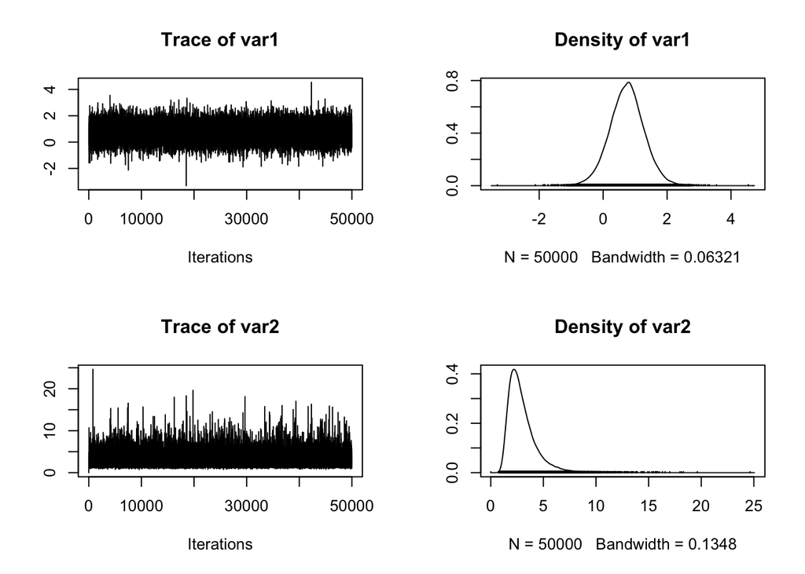

```r
library(coda)
fitRcpp <- as.mcmc(fitRcpp) # Convert the matrix into a "coda" object
plot(fitRcpp)
```